# Data 608 Module 3

Leticia Salazar

10-09-2022

$~$

### Mortality from all 50 states and the District of Colombia

I have provided you with data about mortality from all 50 states and the District of Columbia. Please access it at https://github.com/charleyferrari/CUNY_DATA608/tree/master/module3/data You are invited to gather more data from our provider, the CDC WONDER system, at https://wonder.cdc.gov/ucd-icd10.html.

- This assignment must be done in R. It must be done using the ‘shiny’ package.
- It is recommended you use an R package that supports interactive graphing such as plotly, or vegalite, but this is not required.
- Your apps must be deployed, I won’t be accepting raw files. Luckily, you can pretty easily deploy apps with a free account at shinyapps.io

$~$

#### Load Libraries

```r
library(shiny)
library(tidyverse)
library(ggplot2)
library(rsconnect)
library(plotly)
```

#### Load Data

```r
data <- read.csv("https://raw.githubusercontent.com/charleyferrari/CUNY_DATA_608/master/module3/data/cleaned-cdc-mortality-1999-2010-2.csv", header = TRUE)
```

```r
library(shiny)
library(tidyverse)
library(ggplot2)
library(rsconnect)
library(plotly)
```

```r
glimpse(data)
```

```
Rows: 9,961
Columns: 6
$ ICD.Chapter <chr> "Certain infectious and parasitic diseases", "Certain infec…
$ State       <chr> "AL", "AL", "AL", "AL", "AL", "AL", "AL", "AL", "AL", "AL",…
$ Year        <int> 1999, 2000, 2001, 2002, 2003, 2004, 2005, 2006, 2007, 2008,…
$ Deaths      <int> 1092, 1188, 1211, 1215, 1350, 1251, 1303, 1312, 1241, 1385,…
$ Population  <int> 4430141, 4447100, 4467634, 4480089, 4503491, 4530729, 45698…
$ Crude.Rate  <dbl> 24.6, 26.7, 27.1, 27.1, 30.0, 27.6, 28.5, 28.3, 26.6, 29.4,…
```

```r
summary(data)
```

```
 ICD.Chapter           State                Year          Deaths
 Length:9961        Length:9961        Min.   :1999   Min.   :   10
 Class :character   Class :character   1st Qu.:2002   1st Qu.:  177
 Mode  :character   Mode  :character   Median :2005   Median :  667
                                       Mean   :2005   Mean   : 2929
                                       3rd Qu.:2008   3rd Qu.: 2474
                                       Max.   :2010   Max.   :96511
   Population         Crude.Rate
 Min.   :  491780   Min.   :  0.00
 1st Qu.: 1728292   1st Qu.:  4.60
 Median : 4219239   Median : 24.00
 Mean   : 5937896   Mean   : 52.15
 3rd Qu.: 6562231   3rd Qu.: 50.50
 Max.   :37253956   Max.   :478.40
```

```r
colnames(data)
```

```
[1] "ICD.Chapter" "State"       "Year"        "Deaths"      "Population"
[6] "Crude.Rate"
```

### Question 1:

As a researcher, you frequently compare mortality rates from particular causes across different States. You need a visualization that will let you see (for 2010 only) the crude mortality rate, across all States, from one cause (for example, Neoplasms, which are effectively cancers). Create a visualization that allows you to rank States by crude mortality for each cause of death.

```r
# COD = 'Certain infectious and parasitic diseases'
infec_diseases <- filter(data, Year == '2010' & ICD.Chapter == 'Certain infectious and parasitic diseases')
infec_diseases <- infec_diseases %>%
  arrange(Crude.Rate)
head(infec_diseases)
```

|  | ICD.Chapter | State | Year | Deaths | Population | Crude.Rate |
| --- | --- | --- | --- | --- | --- | --- |
| 1 | Certain infectious and parasitic diseases | UT | 2010 | 274 | 2763885 | 9.9 |
| 2 | Certain infectious and parasitic diseases | ID | 2010 | 174 | 1567582 | 11.1 |
| 3 | Certain infectious and parasitic diseases | ND | 2010 | 83 | 672591 | 12.3 |
| 4 | Certain infectious and parasitic diseases | AK | 2010 | 88 | 710231 | 12.4 |
| 5 | Certain infectious and parasitic diseases | MN | 2010 | 678 | 5303925 | 12.8 |
| 6 | Certain infectious and parasitic diseases | NE | 2010 | 245 | 1826341 | 13.4 |

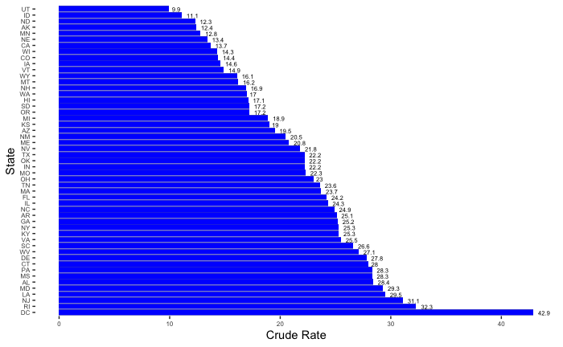

```r
# plot
infec_diseases %>%
ggplot(aes(x = reorder(State, -Crude.Rate), y = Crude.Rate)) +
  geom_bar(stat = "identity") +
  theme(axis.text = element_text(size = 6), panel.background = element_rect(fill = "white")) +
  geom_col(fill = "blue")+
  coord_flip() +
  xlab("State") +
  ylab("Crude Rate") +
  geom_text(aes(label = Crude.Rate), vjust = 0.6, hjust = -0.4, size = 2, color="black")
```

```r
fig <- infec_diseases %>% plot_ly()
fig <- fig %>% add_trace(x = ~Crude.Rate, y = ~State, type = 'bar',
             text = y, textposition = 'auto',
             marker = list(color = 'rgb(158,202,225)',
                           line = list(color = 'rgb(8,48,107)', width = 1.5)))
fig <- fig %>% layout(title = "Certain infectious and parasitic diseases",
         barmode = 'group',
         xaxis = list(title = "Crude rate"),
         yaxis = list(title = "States"))
```

```r
# Define UI for app that draws a histogram ----
ui <- fluidPage(
  # App title ----
  titlePanel("Crude Mortality Rate"),
  # Sidebar layout with input and output definitions ----
  sidebarLayout(
    # Sidebar panel for inputs ----
    sidebarPanel(
      # Input: Slider for the number of bins ----
      selectInput(inputId = 'y','Selected ICD.Chapter:',
                  choices = infec_diseases$ICD.Chapter,
                  selected = 'State')

    ),

    # Main panel for displaying outputs ----
    mainPanel(
      # Output: Histogram ----
      plotlyOutput('distPlot', height = "700px", width = "600px")

    )
  )
)

# Define server logic required to draw a bargraph
server <- function(input, output) {
  output$distPlot <- renderPlotly({fig})
}

# Run the application
shinyApp(ui, server)
# runApp("my_app")
```

### Question 2:

Often you are asked whether particular States are improving their mortality rates (per cause) faster than, or slower than, the national average. Create a visualization that lets your clients see this for themselves for one cause of death at the time. Keep in mind that the national average should be weighted by the national population.

```r
infec_diseases_2 <- filter(data, Year == '2010' & ICD.Chapter == 'Certain infectious and parasitic diseases')
infec_diseases_2 <- data %>%
  arrange(Crude.Rate) %>%
  mutate(Crude.Rate_2 = round(sum(Deaths) / sum(Population) * 10000), 3) %>%
  group_by(Year, ICD.Chapter, State)
head(infec_diseases_2)
```

| ICD.Chapter | State | Year | Deaths | Population | Crude.Rate | Crude.Rate_2 | 3 |
| --- | --- | --- | --- | --- | --- | --- | --- |
| Diseases of the ear and mastoid process | CA | 1999 | 12 | 33499204 | 0 | 5 | 3 |
| Diseases of the ear and mastoid process | CA | 2002 | 11 | 34871843 | 0 | 5 | 3 |
| Diseases of the ear and mastoid process | CA | 2006 | 10 | 36021202 | 0 | 5 | 3 |
| Diseases of the ear and mastoid process | CA | 2009 | 10 | 36961229 | 0 | 5 | 3 |
| Diseases of the ear and mastoid process | TX | 2000 | 10 | 20851820 | 0 | 5 | 3 |
| Diseases of the ear and mastoid process | TX | 2005 | 11 | 22778123 | 0 | 5 | 3 |

```r
colSums(is.na(data))
```

```
ICD.Chapter       State        Year      Deaths  Population  Crude.Rate
          0           0           0           0           0           0
```

```r
# Define UI for app that draws a histogram ----
ui <- fluidPage(
  # App title ----
  titlePanel("Crude Mortality Rate"),
  # Sidebar layout with input and output definitions ----
  sidebarLayout(
    # Sidebar panel for inputs ----
    sidebarPanel(
      # Input: Slider for the number of bins ----
      selectInput(inputId = 'y','Selected ICD.Chapter:',
                  choices = infec_diseases_2$ICD.Chapter,
                  selected = 'State')

    ),

    # Main panel for displaying outputs ----
    mainPanel(
      # Output: Create barchart
      plotlyOutput('distPlot2')

    )
  )
)

server <- function(input, output) {
  output$distPlot2 <- renderPlotly({fig_2})
}

shinyApp(ui, server)
# runApp("my_app")
```

[output not shown]

```r
rsconnect::setAccountInfo(name='letisalba', token='18C2DF783293E23721636AD4A43F97C6', secret='seSfGaZ7eiF653BaFtyAGHFls/Z66OE/t7Sk2b9A')
```

#### References:

- [Plotly](https://plotly.com/r/bar-charts/)